# Statistical Methods

Regression / Inference / Centering

Fall 2025 | Course PSYC 790  
Jeffrey M. Girard | Lecture 09b

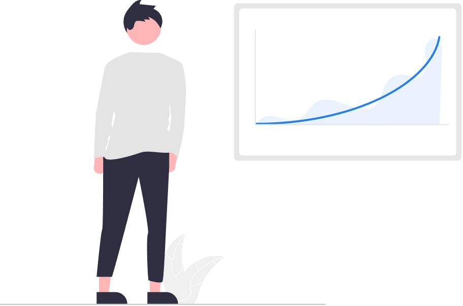

# Introduction

## Regression as Fancy Correlation

- A correlation quantifies how well a **straight line** represents the relationship between two continuous variables

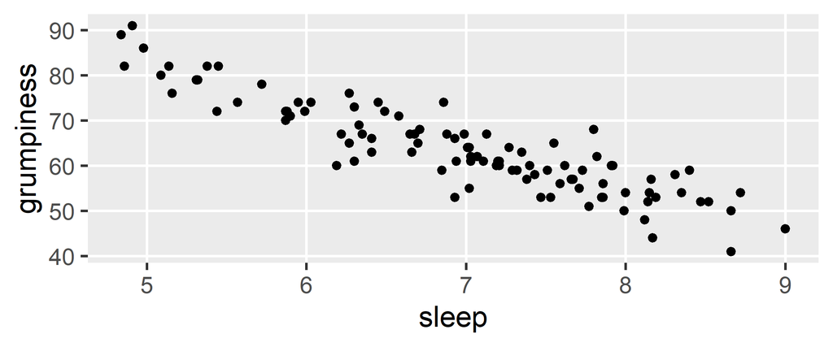

## Regression as Fancy Correlation

- A correlation quantifies how well a straight line represents the relationship between two continuous variables

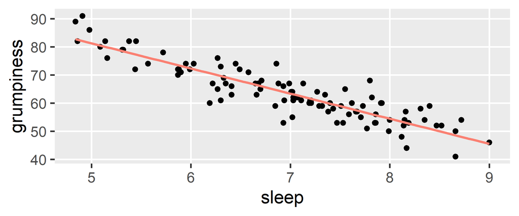

## Regression as Fancy Correlation

- But how did we know *where* to draw the line?
- Many different lines could have been drawn…

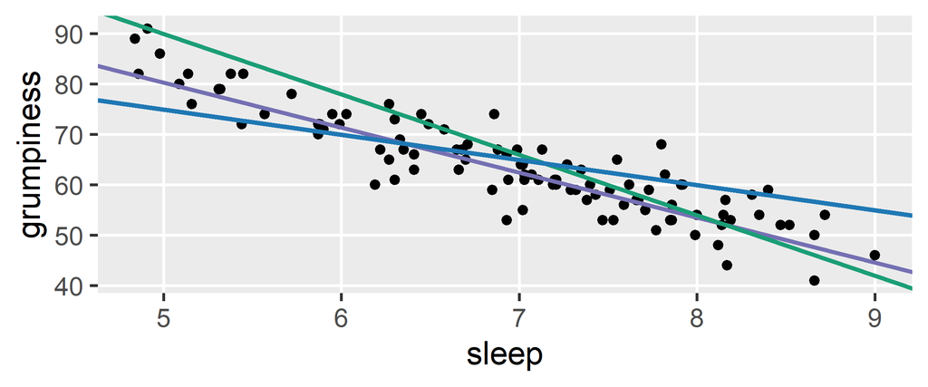

## Regression as Fancy Correlation

- Regression is a way to *select* and *quantify* the “best” line

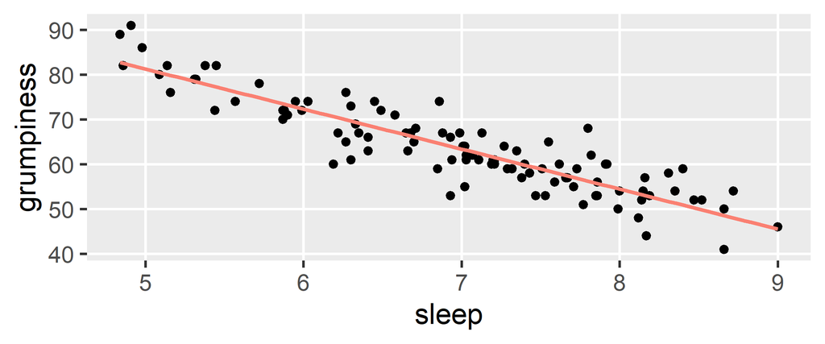

## Defining a Line in General

$$y = \color{blue}{m}x + \color{blue}{b}$$

$y$ and $x$ are variables

$\color{blue}m$ and $\color{blue}b$ are coefficients

- $\color{blue}m$ is the **slope**  
  Change in $y$ when $x+1$
- $\color{blue}b$ is the **intercept**  
  Value of $y$ when $x=0$

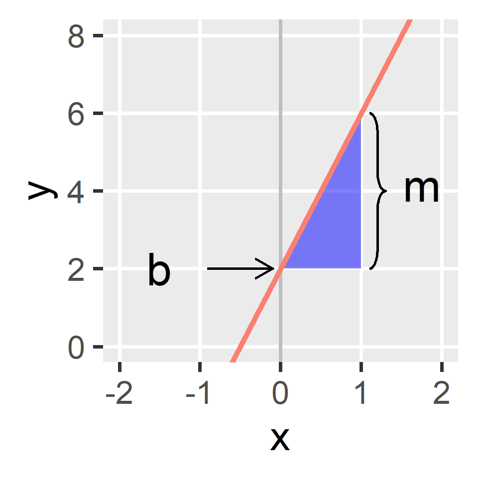

```r
m <- 4
b <- 2
ggplot() +
  geom_polygon(aes(x = c(0, 1, 1), y = c(b, b, b + m)), fill = "blue", alpha = 0.5) +
  geom_vline(xintercept = 0, color = "grey", linewidth = 1.25) +
  geom_abline(intercept = b, slope = m, linewidth = 2, color = "salmon") +
  scale_y_continuous(limits = c(0, 8), breaks = seq(0, 8, 2)) +
  scale_x_continuous(limits = c(-2, 2)) +
  geom_segment(aes(x = -0.9, y = b, xend = -0.1, yend = b), linewidth = 1,
               arrow = arrow(length = unit(0.5, "cm")),
               lineend = "square", linejoin = "mitre") +
  annotate("text", x = -1.5, y = b, label = "b", size = 12) +
  annotate("text", x = 1.75, y = 4.15, label = "m", size = 12) +
  ggbrace::stat_brace(
    aes(x = c(1.1, 1.3), y = c(b, b + m)),
    rotate = 90,
    linewidth = 1,
    outside = FALSE
  ) +
  labs(x = "x", y = "y") +
  mytheme()
```

## Defining a Regression Line

- If $y$ is the outcome and $x$ is the predictor…
- We can define the regression line in the same way

$$\color{red}{\hat{y}_i} = \color{blue}{b_0} + \color{blue}{b_1}x_i$$

$\color{red}{\hat{y}_i}$ is the model-predicted value of $y$ for observation $i$

$\color{blue}{b_0}$ is the intercept of the line (i.e., $b$ on the previous slide)

$\color{blue}{b_1}$ is the slope of the line (i.e., $m$ on the previous slide)

## Defining Regression Residuals

- Our regression line is defined by the formula:

$$\color{red}{\hat{y}_i} = \color{blue}{b_0} + \color{blue}{b_1}x_i$$

- But many points aren’t exactly on the line, so our predictions aren’t perfect

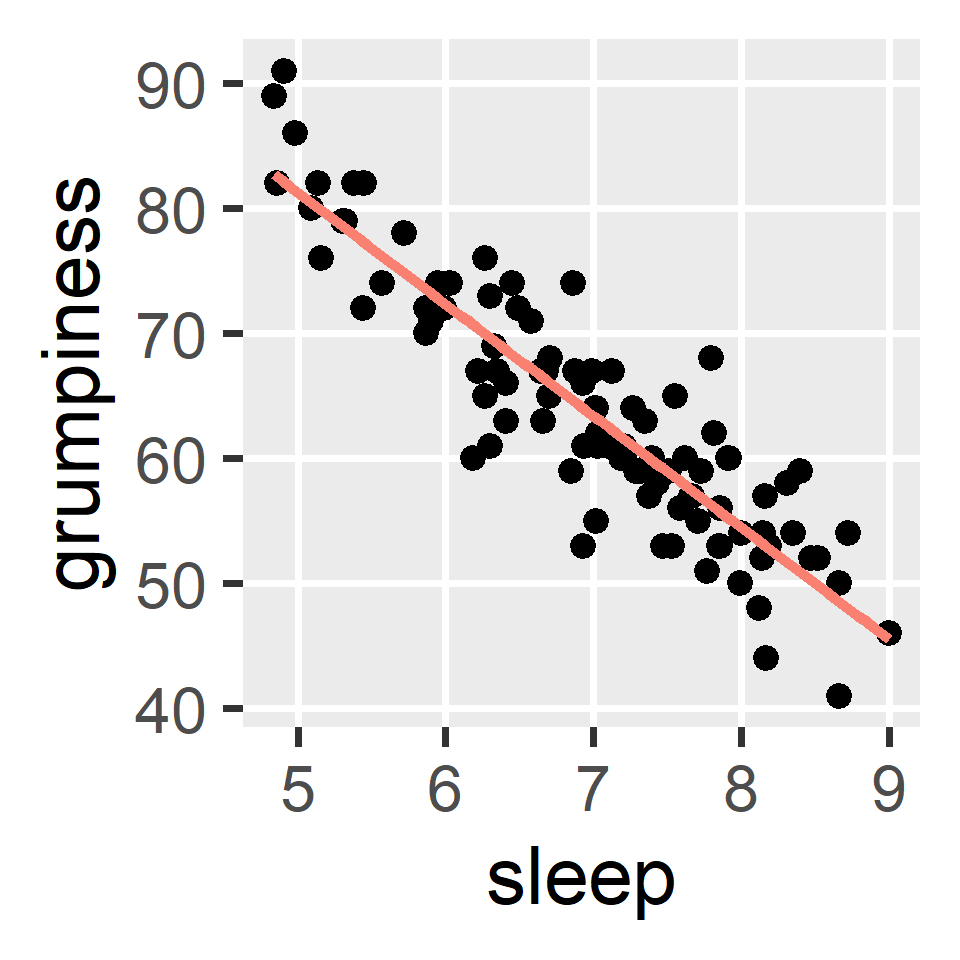

```r
p + geom_smooth(method = "lm", se = FALSE, color = "salmon", linewidth = 2)
```

## Defining Regression Residuals

- Thus, predictions $(\color{red}{\hat{y}_i})$ differ from the observed values $(y_i)$
- We refer to these differences as the model’s residuals

$$\begin{align}
\color{red}{\hat{y}_i} &= \color{blue}{b_0} + \color{blue}{b_1}x_i\\
y_i &= \color{blue}{b_0} + \color{blue}{b_1}x_i + \color{magenta}{e_i} \\
\color{magenta}{e_i} &= y_i - \color{red}{\hat{y}_i}
\end{align}$$

## Visualizing Regression Residuals

```r
fit <- lm(dan.grump ~ dan.sleep, data = parenthood)
p +
  geom_smooth(method = "lm", se = FALSE, color = "salmon", linewidth = 2) +
  geom_segment(aes(x = dan.sleep, xend = dan.sleep,
                   y = dan.grump, yend = dan.grump - residuals(fit)),
               linewidth = 0.75, color = "grey30")
```

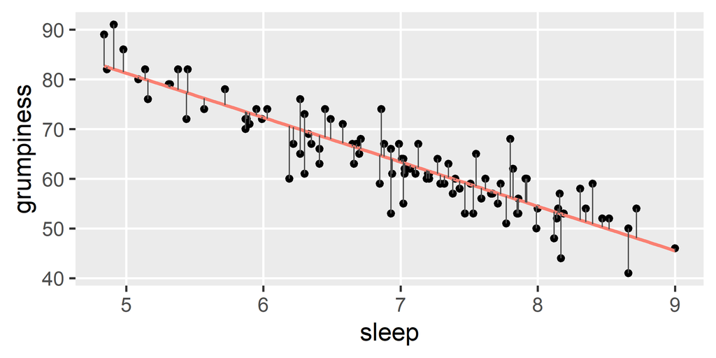

## Minimizing Regression Residuals

- If we want the best possible estimates of $y$, we should…
- …look for the line that minimizes the prediction errors
- Residuals are the prediction errors
- We thus seek to minimize the residuals
- But residuals can be positive or negative…
- So minimizing the sum of the residuals won’t work
- We thus minimize the sum of the *squared* residuals

## OLS Regression

- Minimizing the sum of the squared residuals is called OLS
  - This stands for “Ordinary Least Squares” Regression
- So what are the OLS formulas for the slope and intercept?

$$b_1 = r_{xy}\frac{s_y}{s_x}
\qquad\quad
b_0 = \bar{y} - b_1\bar{x}$$

- Regression and correlation are thus integrally connected

## Example Dataset

The `water` dataset has information about mortality and water hardness in 61 UK towns

```r
water <- read_csv("water.csv")
water
```

| town | location | mortality | hardness |
| --- | --- | --- | --- |
| Bath | South | 1247 | 105 |
| Birkenhead | North | 1668 | 17 |
| Birmingham | South | 1466 | 5 |
| Blackburn | North | 1800 | 14 |
| Blackpool | North | 1609 | 18 |
| Bolton | North | 1558 | 10 |
| Bootle | North | 1807 | 15 |
| Bournemouth | South | 1299 | 78 |
| Bradford | North | 1637 | 10 |
| Brighton | South | 1359 | 84 |
| Bristol | South | 1392 | 73 |
| Burnley | North | 1755 | 12 |
| Cardiff | South | 1519 | 21 |
| Coventry | South | 1307 | 78 |
| Croydon | South | 1254 | 96 |
| Darlington | North | 1491 | 20 |
| Derby | North | 1555 | 39 |
| Doncaster | North | 1428 | 39 |
| East Ham | South | 1318 | 122 |
| Exeter | South | 1260 | 21 |
| Gateshead | North | 1723 | 44 |
| Grimsby | North | 1379 | 94 |
| Halifax | North | 1742 | 8 |
| Huddersfield | North | 1574 | 9 |
| Hull | North | 1569 | 91 |
| Ipswich | South | 1096 | 138 |
| Leeds | North | 1591 | 16 |
| Leicester | South | 1402 | 37 |
| Liverpool | North | 1772 | 15 |
| Manchester | North | 1828 | 8 |
| Middlesbrough | North | 1704 | 26 |
| Newcastle | North | 1702 | 44 |
| Newport | South | 1581 | 14 |
| Northampton | South | 1309 | 59 |
| Norwich | South | 1259 | 133 |
| Nottingham | North | 1427 | 27 |
| Oldham | North | 1724 | 6 |
| Oxford | South | 1175 | 107 |
| Plymouth | South | 1486 | 5 |
| Portsmouth | South | 1456 | 90 |
| Preston | North | 1696 | 6 |
| Reading | South | 1236 | 101 |
| Rochdale | North | 1711 | 13 |
| Rotherham | North | 1444 | 14 |
| St Helens | North | 1591 | 49 |
| Salford | North | 1987 | 8 |
| Sheffield | North | 1495 | 14 |
| Southampton | South | 1369 | 68 |
| Southend | South | 1257 | 50 |
| Southport | North | 1587 | 75 |
| South Shields | North | 1713 | 71 |
| Stockport | North | 1557 | 13 |
| Stoke | North | 1640 | 57 |
| Sunderland | North | 1709 | 71 |
| Swansea | South | 1625 | 13 |
| Wallasey | North | 1625 | 20 |
| Walsall | South | 1527 | 60 |
| West Bromwich | South | 1627 | 53 |
| West Ham | South | 1486 | 122 |
| Wolverhampton | South | 1485 | 81 |
| York | North | 1378 | 71 |

## Data Exploration

```r
p1 <- ggplot(water, aes(x = mortality)) + geom_histogram(bins = 10) +
  mytheme()
p2 <- ggplot(water, aes(x = hardness)) + geom_histogram(bins = 10) +
  mytheme()
p3 <- ggplot(water, aes(x = hardness, y = mortality)) + geom_point(size = 2) +
  mytheme()
(p1 / p2) | p3
```

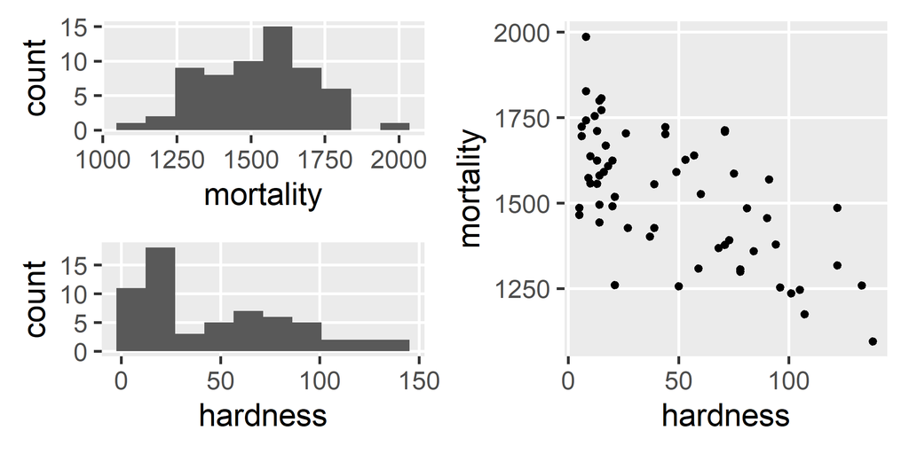

## OLS Regression by Hand

```r
x <- water$hardness
y <- water$mortality

b1 <- cor(x, y) * sd(y) / sd(x)
b1
## [1] -3.226092

b0 <- mean(y) - b1 * mean(x)
b0
## [1] 1676.356
```

$$\hat{y}_i = 1676.356 - 3.226 x_i$$

“We estimate that a town with a water hardness of zero would have a mortality of 1676.356. For every one-unit increase in a town’s water hardness, we estimate that its mortality would *decrease* by 3.226.”

## Visualizing our Result

```r
qplot(x = hardness, y = mortality, data = water, geom = "point") +
  geom_abline(slope = b1, intercept = b0, color = "salmon")
```

```r
ggplot(water, aes(x = hardness, y = mortality)) +
  geom_point(size = 3) +
  geom_abline(slope = b1, intercept = b0, linewidth = 2, color = "salmon") +
  mytheme()
```

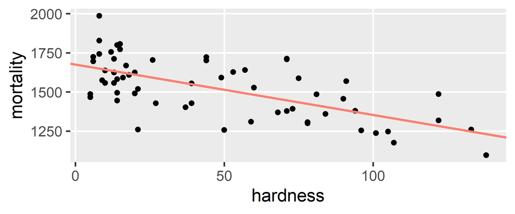

## Regression using lm()

```r
fit <- lm(formula = mortality ~ hardness, data = water)
fit
##
## Call:
## lm(formula = mortality ~ hardness, data = water)
##
## Coefficients:
## (Intercept)     hardness
##    1676.356       -3.226
```

- Just like before, the formula is `outcome ~ predictor`
- R refers to $b_0$ as `(Intercept)` and $b_1$ as `hardness`
- This will be helpful when we add multiple predictors

# Regression Inference

## Uncertainty in the Population

- OLS finds the best coefficients *for the sample*
- But we usually care more about the **population**
- Thus, we *estimate* the population intercept and slope
- There will be some inferential uncertainty in this process
- As before, we can use NHST and/or estimation approaches
- Let’s calculate 95% CIs, test statistics, and $p$-values

## Slope Confidence Interval

$$b_1 \pm \text{SE}(b_1)\times t_{crit}$$

$$\text{SE}(b_1) = \frac{s_y}{s_x}\sqrt{\frac{1-r_{xy}^2}{n-2}}$$

$$t_{crit}\text{ comes from the } t(n-2, 0, 1)\text{ distribution}$$

## Intercept Confidence Interval

$$b_0 \pm \text{SE}(b_0)\times t_{crit}$$

$$\text{SE}(b_0) = \sqrt{\frac{\sum_i(y_i-\hat{y}_i)^2}{n-2}} \sqrt{\frac{1}{n} + \frac{\bar{x}^2}{(n-1)s_x^2}}$$

$$t_{crit}\text{ comes from the } t(n-2, 0, 1)\text{ distribution}$$

## Confidence Intervals in R

```r
fit
##
## Call:
## lm(formula = mortality ~ hardness, data = water)
##
## Coefficients:
## (Intercept)     hardness
##    1676.356       -3.226

confint(fit)
##                  2.5 %      97.5 %
## (Intercept) 1617.73030 1734.980903
## hardness      -4.19602   -2.256163
```

- I’ll show you the {easystats} way after we cover NHST

## Plotting Regression Results

```r
# install.packages(c("ggeffects", "effects"))
library(ggeffects)
est <- predict_response(fit, "hardness")
plot(est, show_data = TRUE)
```

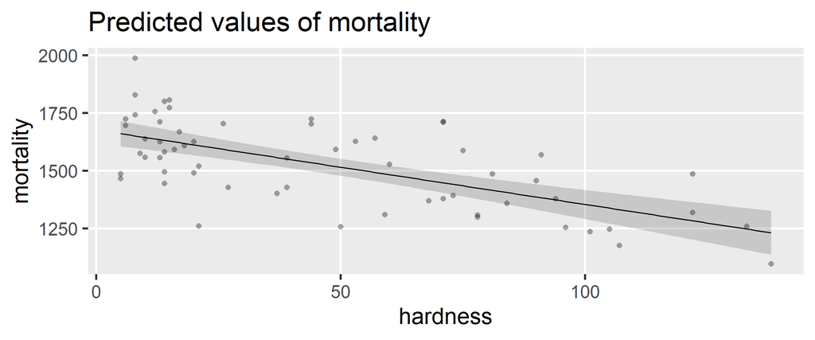

## Hypothesis Testing

**Null:** The true coefficient (in the population) is zero

$$H_0: b = 0$$

**Alternative:** The true coefficient (in the population) is *not* zero

$$H_1: b \neq 0$$

Note that this applies to both intercepts and slopes

## Testing Individual Coefficients

- We can re-use the logic/procedure of the one-sample $t$-test
- We assume the null sampling distribution for $\hat{b}$ is normal

$$t_{obs} = \frac{b}{\text{SE}(b)}$$

$$t_{obs} \sim t(\mathit{df}=n-k-1, \mu=0, \sigma=1)$$

Note that $k$ is the number of predictors in the model (i.e., 1 for now).

## Statistical Inference in R

```r
library(easystats)
model_parameters(fit)
## Parameter   | Coefficient |    SE |             95% CI | t(59) |      p
## -----------------------------------------------------------------------
## (Intercept) |     1676.36 | 29.30 | [1617.73, 1734.98] | 57.22 | < .001
## hardness    |       -3.23 |  0.48 | [  -4.20,   -2.26] | -6.66 | < .001
```

“A town with zero water hardness is expected to have a mortality rate of 1676.36, which is significantly different from zero, 95% CI: [1617.73, 1734.98], *p*<.001. For each one-unit increase in water hardness, the model predicts a significant decrease in mortality of 3.23, 95% CI: [–4.20, –2.26], *p*<.001.”

Note that the $t$ values equal Coefficient / SE (e.g., –3.23/0.48 ≈ –6.66).

# Centering

## Centering a Predictor

- The intercept $(b_0)$ is the value of $\hat{y}$ when $x=0$
- This isn’t so useful if $x$ never equals $0$ in the sample
- In such cases, it can be useful to “center” $x$ before modeling

$$x_i^c = x_i - \bar{x}$$

```r
xc <- x - mean(x)
```

- The **slope will stay the same** but the intercept will change
- The intercept will become the value of $\hat{y}$ when $x=\bar{x}$

## Centering a Predictor

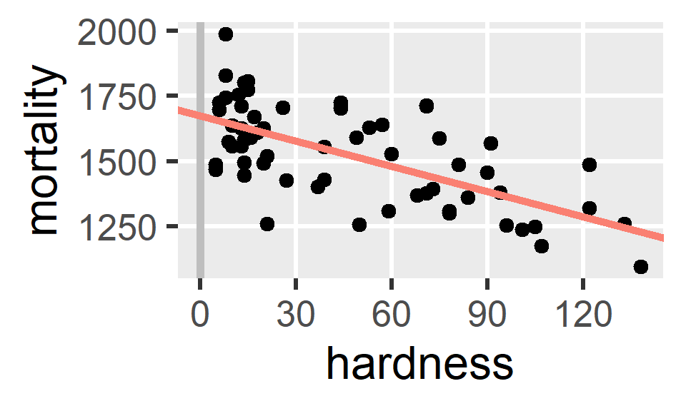

```r
ggplot(water, aes(x = hardness, y = mortality)) +
  geom_vline(xintercept = 0, color = "grey", linewidth = 2) +
  geom_point(size = 2.5) +
  geom_abline(slope = -3.226, intercept = 1676.356, linewidth = 2, color = "salmon") +
  scale_x_continuous(breaks = seq(0, 120, 30)) +
  mytheme(24)
```

$$b_0 = 1676.356$$

“A town with *zero* water hardness  
would have 1676.356 mortality.”

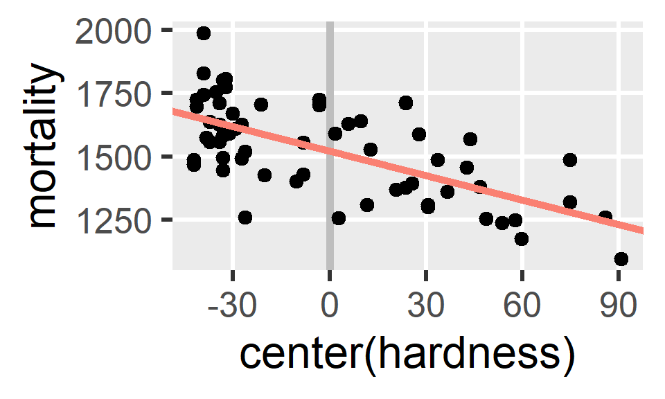

```r
ggplot(water, aes(x = hardness - mean(hardness), y = mortality)) +
  geom_vline(xintercept = 0, color = "grey", linewidth = 2) +
  geom_point(size = 2.5) +
  geom_abline(slope = -3.226, intercept = 1524.148, linewidth = 2, color = "salmon") +
  scale_x_continuous(breaks = seq(-30, 90, 30)) +
  labs(x = "center(hardness)") +
  mytheme(24)
```

$$b_0 = 1524.148$$

“A town with *average* water hardness  
would have 1524.148 mortality.”

## Centering in R

```r
# Two-step process
water$hardness_c <- water$hardness - mean(water$hardness)

fit2a <- lm(formula = mortality ~ hardness_c, data = water)
model_parameters(fit2a)
## Parameter   | Coefficient |    SE |             95% CI | t(59) |      p
## -----------------------------------------------------------------------
## (Intercept) |     1524.15 | 18.31 | [1487.50, 1560.79] | 83.23 | < .001
## hardness c  |       -3.23 |  0.48 | [  -4.20,   -2.26] | -6.66 | < .001
```

```r
# Or equivalent one-step process
fit2b <- lm(formula = mortality ~ center(hardness), data = water)
model_parameters(fit2b)
## Parameter        | Coefficient |    SE |             95% CI | t(59) |      p
## ----------------------------------------------------------------------------
## (Intercept)      |     1524.15 | 18.31 | [1487.50, 1560.79] | 83.23 | < .001
## center(hardness) |       -3.23 |  0.48 | [  -4.20,   -2.26] | -6.66 | < .001
```

# Regression Effect Sizes

## Standardized Slopes

- It is common to standardize regression slopes (called $\beta$s)
- We can do this by standardizing both $y$ and $x$ and refitting

$$x_i^z = \frac{x_i - \bar{x}}{s_x} \qquad \quad y_i^z = \frac{y_i - \bar{y}}{s_y}$$

$$\hat{y}_i^z = \beta_0 + \beta_1x_i^z$$

- The standardized slope $(\beta_1)$ is interpreted in SD units
- The standardized intercept $(\beta_0)$ will equal/approach zero

## Standardizing in R

```r
# Method 1: Fit normally then refit
fit <- lm(mortality ~ hardness, data = water)
model_parameters(fit, standardize = "refit")
## Parameter   | Coefficient |   SE |         95% CI |     t(59) |      p
## ----------------------------------------------------------------------
## (Intercept) |   -4.55e-16 | 0.10 | [-0.20,  0.20] | -4.66e-15 | > .999
## hardness    |       -0.65 | 0.10 | [-0.85, -0.46] |     -6.66 | < .001

# Method 2: Standardize data then fit
fit2 <- lm(mortality ~ hardness, data = standardize(water))
model_parameters(fit2)
## Parameter   | Coefficient |   SE |         95% CI |     t(59) |      p
## ----------------------------------------------------------------------
## (Intercept) |   -4.55e-16 | 0.10 | [-0.20,  0.20] | -4.66e-15 | > .999
## hardness    |       -0.65 | 0.10 | [-0.85, -0.46] |     -6.66 | < .001
```

“For each one SD increase in water hardness, we would expect a 0.65 SD  
*decrease* in mortality, $\beta=-0.65$, 95% CI: $[-0.85, -0.46]$, $p<.001$.”

## R-Squared

- $R^2$ is the variance in $y$ explained by the regression model
  - Ranges from 0.0 (0% explained) to 1.0 (100% explained)
  - It is equivalent to squaring the correlation of $y$ and $\hat{y}$
  - It is also called the “coefficient of determination”

$$R^2 = 1 - \frac{\text{SS}_{res}}{\text{SS}_{tot}} = 1 - \frac{\sum_i(y_i - \hat{y}_i)^2}{\sum_i(y_i - \bar{y})^2}$$

## Adjusted R-Squared

- $R^2$ will never decrease when adding more predictors
- So we often adjust it to penalize adding more predictors

$$R_{adj}^2 = 1 - \left(\frac{\text{SS}_{res}}{\text{SS}_{tot}} \times \frac{n - 1}{n - k - 1}\right)$$

- Negative values of $R_{adj}^2$ are possible
- Its interpretation is less straightforward

## Model Performance in R

```r
# By hand (with the residuals function shortcut)
R2a <- 1 - sum(residuals(fit)^2) / sum((y - mean(y))^2)
R2a
## [1] 0.4288267

# By function (recommended)
R2b <- r2(fit, ci = 0.95)
R2b
##        R2: 0.429 [0.230, 0.601]
##   adj. R2: 0.419 [0.220, 0.593]
```

“The regression model in which mortality was regressed on water hardness explained 42.9% of the variance in mortality, R² = 0.429, 95% CI: [0.230, 0.601], Adjusted R² = 0.419.”